# ECON 4/6260 - Behaviroal Economics

## Markets

- Probably one of the first things you learned about in a *Principles of Microeconomics* course
- A group of buyers, each with values for purchasing items
  - Implies a downward-sloping demand curve
- A group of sellers, each with costs of selling item
  - Implies an upward-sloping supply curve
- This is enough to calculate the equilibrium price and quantity

However: * One cannot just ask buyers what there values are * One cannot just ask sellers what their values are

(why not?)

## An experiment

…

## Induced value theory

Simple version: *Pay people enough money, and they will behave as if these are their incentives*

More formally, if for a participant in an experiment: * taking action \(a\) results in payment $A * taking action \(b\) results in payment $B

Then they will only choose action \(a\) if \(A \geq B\), and will only choose action \(b\) if \(B\geq A\).

**Caveats**: \(A\) and \(B\) need to be large enough that participants pay attention to them (salience)

- Don’t pay in Monopoly money, chocolate, etc
- Maintain assumption that participants don’t care about the earnings of others (selfishness)
- Participants need to understand how their actions lead to payments
- Participants need to believe that their actions will lead to payments

## In market experiments

- Each buyer \(i\) has values \(v_{i,1}\geq v_{i,2}\geq v_{i,3} \ldots\).
- Each seller \(j\) has costs \(c_{i,1}\leq c_{i,2}\leq c_{i,3} \ldots\).
- If buyer \(i\) buys from seller \(j\) at price \(p\):
  - Buyer \(i\) earns \(\$ v_{i,1}-p\)
  - Seller \(j\) earns \(\$ p-c_{j,1}\)

(if this is the first trade for both)

## Numerical example - Buyers

There are 10 buyers, each buyer has a value equal to a 15-sided die roll plus 3, and can buy at most 3 items:

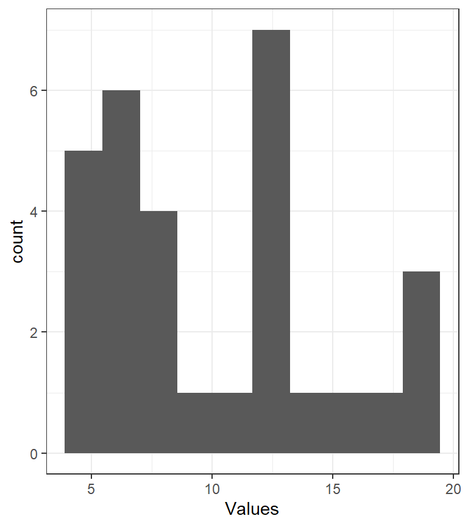

```r
set.seed(42)
nBuyers<-10
nItems<-3
Demand<-data.frame()
for (bb in 1:nBuyers) {
  # value for that individual buyer
  v<-sample(1:15,nItems,replace=T)+3
  tmp<-data.frame(v)
  tmp$BuyerID<-bb
  Demand<-rbind(Demand,tmp)
}
plt<-(
  ggplot(data=Demand,aes(x=v))+geom_histogram(bins=10)
  +theme_bw()
  +xlab("Values")
  +ylab("count")
)
```

## Numerical example - Sellers

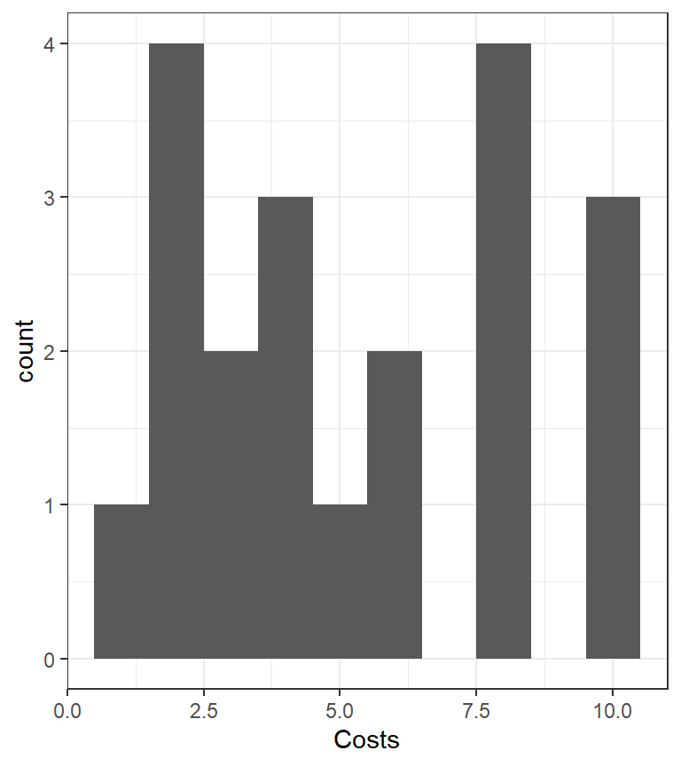

```r
nSellers<-10
nItems<-2
Supply<-data.frame()
for (ss in 1:nSellers) {
  # value for that individual buyer
  c<-sample(1:10,nItems,replace=T)
  tmp<-data.frame(c)
  tmp$SellerID<-ss
  Supply<-rbind(Supply,tmp)
}
plt<-(
  ggplot(data=Supply,aes(x=c))+geom_histogram(bins=10)
  +theme_bw()
  +xlab("Costs")
  +ylab("count")
)
```

## Numerical example - Supply and demand curves

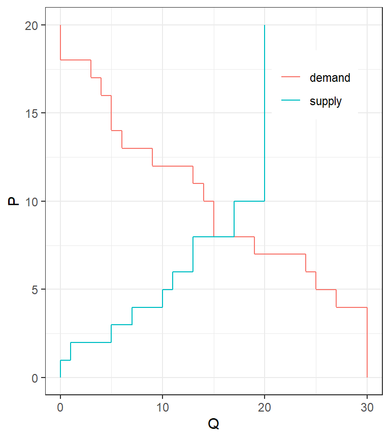

```r
P<-seq(0,20,length=1000) # prices to evaluate quantity
SF<-function(p) {
  sum(Supply$c<=p)
}
DF<-function(p) {
  sum(Demand$v>=p)
}

SupplyDemand<-data.frame()
for (pp in P) {
  p<-pp
  Q<-DF(pp)
  type="demand"
  SupplyDemand<-rbind(SupplyDemand,data.frame(p,Q,type))
  Q<-SF(pp)
  type="supply"
  SupplyDemand<-rbind(SupplyDemand,data.frame(p,Q,type))

}
plt<-(ggplot(data=SupplyDemand,aes(x=Q,y=p,color=type))
  +geom_path()+theme_bw()
  +xlab("Q")+ylab("P")
  +theme(legend.title = element_blank(),
         legend.position=c(0.8,0.8))
)
```

## Point predictions from markets

- Equilibrium price and quantity
- Which buyers trade?
- Which sellers trade?
- Consumer and producer surplus

```r
ExcessDemand<-apply(as.matrix(P),
                    FUN = function(x) {DF(x)-SF(x)},
                    MARGIN=1)

Peq<-P[which.min(abs(ExcessDemand))]
Qeq<-c(DF(Peq),SF(Peq))

# equilibrium price
print(Peq)
```

```
## [1] 8.008008
```

```r
# equilibrium quantity
print(Qeq)
```

```
## [1] 15 17
```

## Point predictions

```r
plt<-(plt
      +geom_hline(yintercept=Peq,
                  color="black",
                  linetype="dashed")
      +geom_vline(xintercept=Qeq,
                  color="black",
                  linetype="dashed")
)

CS<-sum((Demand %>% filter(v>=Peq))$v)
print(CS)
```

```
## [1] 209
```

```r
PS<-sum((Supply %>% filter(c<=Peq))$c)
print(PS)
```

```
## [1] 76
```

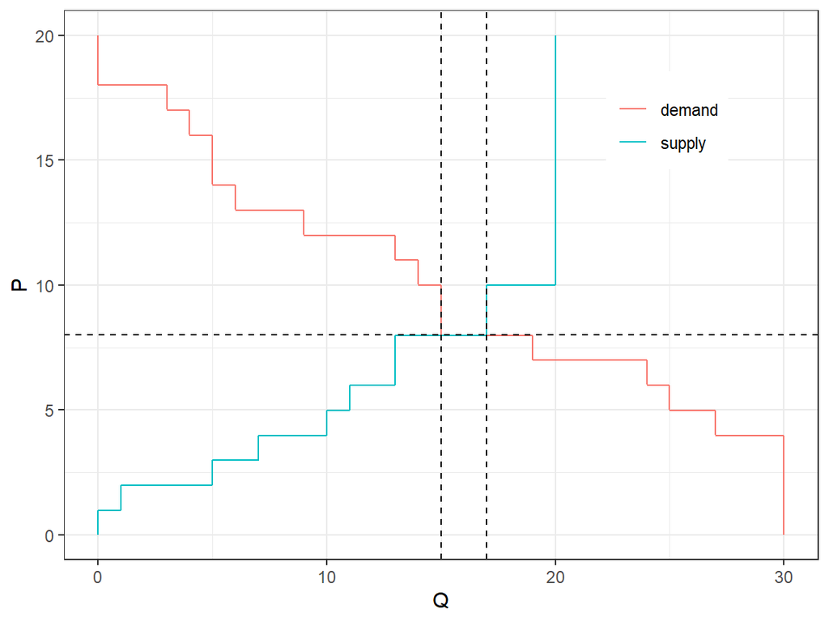

## Comparative static predictions

What happens to any of the above if?

- Supply or demand shift?
- The government imposes a tax?
- The government subsidizes the good?
- The government imposes a price floor or ceiling?

## Other take-aways

- Market theory remains silent on *how* buyers and sellers discover the equilibrium price
- Market theory remains silent on whether different trading mechanisms affect price discovery.